# Laboratorio 2 - Modelli VAR

## **LABORATORIO 2 - MODELLI VAR**

[figure not shown]

```r
library(forecast)
library(vars)
```

```r
setwd("C:/Users/fra24/OneDrive/Documenti/uni/magistrale/economici/lab2")
uschange = read.csv("fpp3_uschange.csv")
str(uschange)
```

```
'data.frame':   198 obs. of  6 variables:
 $ Quarter     : chr  "1970 Q1" "1970 Q2" "1970 Q3" "1970 Q4" ...
 $ Consumption : num  0.619 0.452 0.873 -0.272 1.901 ...
 $ Income      : num  1.04 1.23 1.59 -0.24 1.98 ...
 $ Production  : num  -2.452 -0.551 -0.359 -2.186 1.91 ...
 $ Savings     : num  5.3 7.79 7.4 1.17 3.54 ...
 $ Unemployment: num  0.9 0.5 0.5 0.7 -0.1 ...
```

```r
uschange = ts(uschange[, -1], start = c(1970, 1), frequency = 4)
end(uschange)
```

```
[1] 2019    2
```

Andremo a fare dei modelli con serie univariate e con dei modelli VAR ed andremo tramite delle previsioni a confrontare i modelli in termini di prestazioni. Vedremo se l’utilizzo dei VAR porta a previsioni migliori.

Dividiamo in stima e verifica.

Si può usare MSE di previsione per confrontare i modelli. Le previsioni sono condizionate al periodo di riferimento, ci possono essere periodi buoni o cattivi.

Avro tante previsioni di tanti passi in avanti, posso calcolare MSE di previsioni dei passi in avanti (fino a 10) per ottenere la performance previsiva. Mi aspetto che l’errore di prev aumenti il all’aumentare del passo. Nella decima previsione, non cotterà solo l’incertezza dei passi, ma anche le previsioni (e quindi le loro incertezze) ottenute ai passi precedenti.

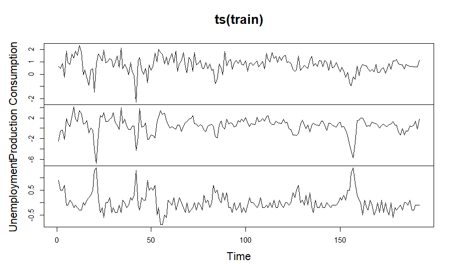

```r
train = window(uschange[, c(1,3,5)], end = c(2017, 4))
test = window(uschange[, c(1,3,5)], start = c(2018, 1))
plot(ts(train))
```

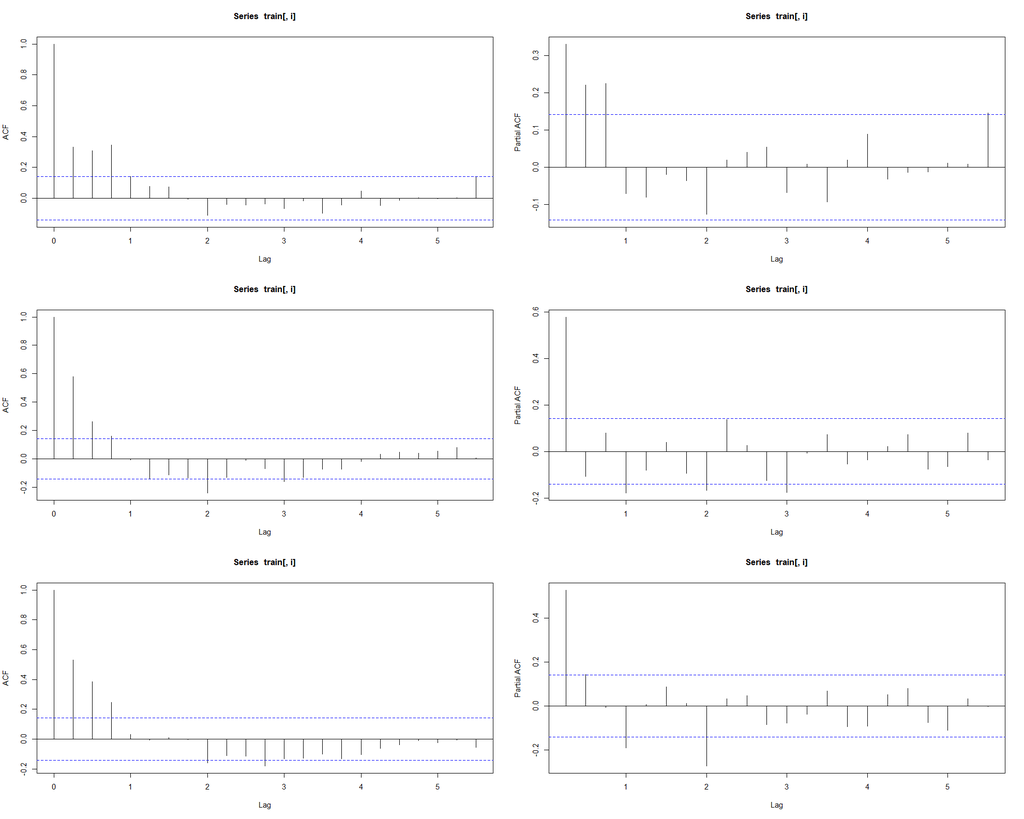

```r
par(mfrow = c(3,2))
for (i in 1:NCOL(train)) {
  acf(train[,i], main = colnames(train[i]))
  pacf(train[,i], main = colnames(train[i]))
}
par(mfrow = c(1,1))
```

1. per la prima può sembrare un AR(3), non sembra esserci stagionalità
2. non considero la comp stagionale anche se presente
3. uno, due ritardi significativi AR(2), c’è un pò di stagionalità residua

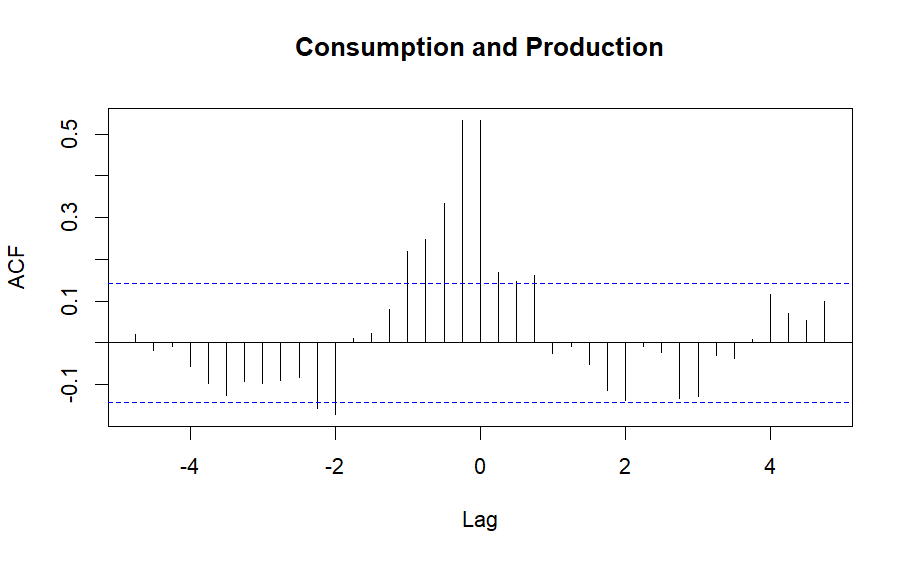

```r
par(mfrow = c(1,1))
ccf(train[,1], train[,2], main ="Consumption and Production")
```

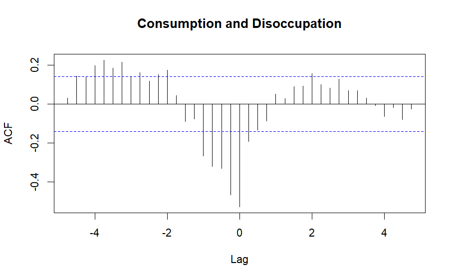

```r
ccf(train[,1], train[,3], main ="Consumption and Disoccupation")
```

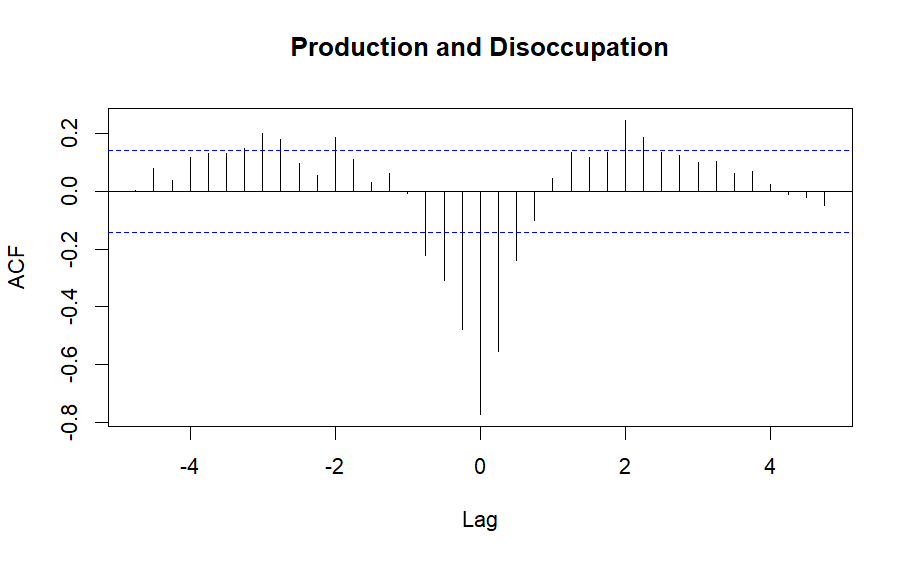

```r
ccf(train[,2], train[,3], main ="Production and Disoccupation")
par(mfrow = c(1,1))
```

Iniziamo la modellazione con i VAR

Per identificare i gradi del var possiamo usare i criteri di informazione

```r
ICsel = VARselect(train, type = "const", lag.max = 5)
ICsel$selection
```

```
AIC(n)  HQ(n)  SC(n) FPE(n)
     3      2      1      3
```

```r
ICsel$criteria
```

```
                1           2           3           4           5
AIC(n) -3.9264256 -4.05302988 -4.07696141 -4.06672657 -3.99995119
HQ(n)  -3.8424098 -3.90600220 -3.86692188 -3.79367517 -3.66388792
SC(n)  -3.7190818 -3.69017811 -3.55860174 -3.39285900 -3.17057571
FPE(n)  0.0197144  0.01737149  0.01696412  0.01714493  0.01833959
```

```r
ICsel = VARselect(train, type = "none", lag.max = 5)
ICsel$selection
```

```
AIC(n)  HQ(n)  SC(n) FPE(n)
     3      3      2      3
```

```r
ICsel$criteria
```

```
                 1           2           3           4           5
AIC(n) -3.53563572 -3.89653126 -3.99483939 -3.97458715 -3.93112264
HQ(n)  -3.47262385 -3.77050753 -3.80580381 -3.72253970 -3.61606333
SC(n)  -3.38012781 -3.58551546 -3.52831569 -3.35255554 -3.15358313
FPE(n)  0.02914047  0.02031359  0.01841451  0.01879701  0.01964198
```

I primi tre criteri danno risultati diversi, andiamo a stimare allora i VAR consigliati dai tre criteri separatamente.

#### VAR(1)

Non vediamo l’effetto simultaneo perchè gli errori sono correlati tra loro.

Abbiamo una serie trivaria, e per ogni serie la vedremo in relazioni ai ritardi precedenti delle altre serie e se stessa.

```r
mod1 = VAR(train, p=1)
summary(mod1)
```

```
VAR Estimation Results:
=========================
Endogenous variables: Consumption, Production, Unemployment
Deterministic variables: const
Sample size: 191
Log Likelihood: -429.355
Roots of the characteristic polynomial:
0.4344 0.3356 0.1724
Call:
VAR(y = train, p = 1)


Estimation results for equation Consumption:
============================================
Consumption = Consumption.l1 + Production.l1 + Unemployment.l1 + const

                Estimate Std. Error t value Pr(>|t|)
Consumption.l1   0.32849    0.08347   3.935 0.000117 ***
Production.l1   -0.02219    0.04688  -0.473 0.636540
Unemployment.l1 -0.10433    0.19336  -0.540 0.590126
const            0.51299    0.07584   6.764 1.67e-10 ***
---
Signif. codes:  0 ‘***’ 0.001 ‘**’ 0.01 ‘*’ 0.05 ‘.’ 0.1 ‘ ’ 1


Residual standard error: 0.6144 on 187 degrees of freedom
Multiple R-Squared: 0.1116, Adjusted R-squared: 0.0974
F-statistic: 7.834 on 3 and 187 DF,  p-value: 5.937e-05


Estimation results for equation Production:
===========================================
Production = Consumption.l1 + Production.l1 + Unemployment.l1 + const

                Estimate Std. Error t value Pr(>|t|)
Consumption.l1   0.68272    0.15831   4.313 2.61e-05 ***
Production.l1    0.28736    0.08891   3.232  0.00145 **
Unemployment.l1 -0.75260    0.36672  -2.052  0.04154 *
const           -0.12484    0.14384  -0.868  0.38653
---
```

[output cut: 23 more lines]

```
F-statistic:  32.5 on 3 and 187 DF,  p-value: < 2.2e-16



Covariance matrix of residuals:
             Consumption Production Unemployment
Consumption      0.37749     0.3577     -0.08987
Production       0.35770     1.3578     -0.22345
Unemployment    -0.08987    -0.2235      0.09002

Correlation matrix of residuals:
             Consumption Production Unemployment
Consumption       1.0000     0.4996      -0.4876
Production        0.4996     1.0000      -0.6392
Unemployment     -0.4876    -0.6392       1.0000
```

Si possono vedere dei coefficienti non significativi per le varie serie nei 3 modelli differenti. Rispecchiamo quello visto dalle ccf.

Inoltre c’è la matrice di covarianza e correlazione dei residui.

#### VAR(2)

```r
mod2 = VAR(train, p = 2)
summary(mod2)
```

```
VAR Estimation Results:
=========================
Endogenous variables: Consumption, Production, Unemployment
Deterministic variables: const
Sample size: 190
Log Likelihood: -405.509
Roots of the characteristic polynomial:
0.6344 0.6344 0.479 0.2745 0.2495 0.1586
Call:
VAR(y = train, p = 2)


Estimation results for equation Consumption:
============================================
Consumption = Consumption.l1 + Production.l1 + Unemployment.l1 + Consumption.l2 + Production.l2 + Unemployment.l2 + const

                Estimate Std. Error t value Pr(>|t|)
Consumption.l1   0.33353    0.08510   3.919 0.000125 ***
Production.l1   -0.08679    0.05117  -1.696 0.091566 .
Unemployment.l1 -0.03081    0.19651  -0.157 0.875586
Consumption.l2   0.27317    0.08635   3.164 0.001825 **
Production.l2    0.03760    0.04795   0.784 0.433921
Unemployment.l2  0.06919    0.19584   0.353 0.724291
const            0.32147    0.09182   3.501 0.000582 ***
---
Signif. codes:  0 ‘***’ 0.001 ‘**’ 0.01 ‘*’ 0.05 ‘.’ 0.1 ‘ ’ 1


Residual standard error: 0.5992 on 183 degrees of freedom
Multiple R-Squared: 0.1721, Adjusted R-squared: 0.145
F-statistic: 6.341 on 6 and 183 DF,  p-value: 4.438e-06


Estimation results for equation Production:
===========================================
Production = Consumption.l1 + Production.l1 + Unemployment.l1 + Consumption.l2 + Production.l2 + Unemployment.l2 + const

                Estimate Std. Error t value Pr(>|t|)
Consumption.l1   0.61037    0.16573   3.683 0.000303 ***
Production.l1    0.32561    0.09965   3.268 0.001296 **
```

[output cut: 32 more lines]

```
F-statistic: 17.11 on 6 and 183 DF,  p-value: 1.167e-15



Covariance matrix of residuals:
             Consumption Production Unemployment
Consumption      0.35910     0.3677     -0.08825
Production       0.36772     1.3619     -0.23671
Unemployment    -0.08825    -0.2367      0.08876

Correlation matrix of residuals:
             Consumption Production Unemployment
Consumption       1.0000     0.5258      -0.4943
Production        0.5258     1.0000      -0.6808
Unemployment     -0.4943    -0.6808       1.0000
```

Nella prima serie risultano significativi i consumi a t-1 e t-2, mentre a t-2 e t-1 di prod e disoccupazione nono sono significativi

Nell’equazione della produzione a t-1 sono significativi produzione e consumi e disoccupazione a t-2 ninete è significativo.

Nella terza serie, disoccupazione a t-1 e t-2 e consumo a t-1

```r
mod3 = VAR(train, p = 3)
summary(mod3)
```

```
VAR Estimation Results:
=========================
Endogenous variables: Consumption, Production, Unemployment
Deterministic variables: const
Sample size: 189
Log Likelihood: -393.191
Roots of the characteristic polynomial:
0.773 0.773 0.5426 0.5426 0.4787 0.4787 0.441 0.09338 0.09338
Call:
VAR(y = train, p = 3)


Estimation results for equation Consumption:
============================================
Consumption = Consumption.l1 + Production.l1 + Unemployment.l1 + Consumption.l2 + Production.l2 + Unemployment.l2 + Consumption.l3 + Production.l3 + Unemployment.l3 + const

                Estimate Std. Error t value Pr(>|t|)
Consumption.l1   0.24090    0.08629   2.792 0.005813 **
Production.l1   -0.08150    0.05290  -1.541 0.125199
Unemployment.l1 -0.11037    0.20195  -0.547 0.585382
Consumption.l2   0.27169    0.08697   3.124 0.002081 **
Production.l2   -0.02668    0.05386  -0.495 0.620955
Unemployment.l2  0.07754    0.19609   0.395 0.692989
Consumption.l3   0.29571    0.08653   3.417 0.000783 ***
Production.l3    0.07266    0.04677   1.554 0.122057
Unemployment.l3  0.35830    0.20026   1.789 0.075284 .
const            0.16259    0.09778   1.663 0.098103 .
---
Signif. codes:  0 ‘***’ 0.001 ‘**’ 0.01 ‘*’ 0.05 ‘.’ 0.1 ‘ ’ 1


Residual standard error: 0.5806 on 179 degrees of freedom
Multiple R-Squared: 0.2398, Adjusted R-squared: 0.2016
F-statistic: 6.273 on 9 and 179 DF,  p-value: 1.075e-07


Estimation results for equation Production:
===========================================
Production = Consumption.l1 + Production.l1 + Unemployment.l1 + Consumption.l2 + Production.l2 + Unemployment.l2 + Consumption.l3 + Production.l3 + Unemployment.l3 + const

```

[output cut: 41 more lines]

```
F-statistic: 11.28 on 9 and 179 DF,  p-value: 6.751e-14



Covariance matrix of residuals:
             Consumption Production Unemployment
Consumption       0.3370     0.3541     -0.08540
Production        0.3541     1.3645     -0.23938
Unemployment     -0.0854    -0.2394      0.08949

Correlation matrix of residuals:
             Consumption Production Unemployment
Consumption       1.0000     0.5221      -0.4917
Production        0.5221     1.0000      -0.6850
Unemployment     -0.4917    -0.6850       1.0000
```

Lasciamo perdere :)

Prima però di scegliere facciamo l’analisi dei residui per effetivamente scegliere il modello più adeguato.

```r
res1 = residuals(mod1)
res2 = residuals(mod2)
res3 = residuals(mod3)
```

bisogna controllare se le tre serie di residui di ogni modello sono dei WN, altrimenti il modello non va bene.

```r
head(res1, 10) #sempre trivariati, ho i residui per ogni serie
```

```
    Consumption  Production Unemployment
1  -0.224715831  0.53316417   0.12284052
2   0.251342479 -0.00761901   0.27422392
3  -1.027356313 -2.17741072   0.53777898
4   1.502190854  3.37510291  -0.53063545
5  -0.190738336 -0.89571954   0.13075112
6  -0.009832671 -0.52606479   0.16887567
7   0.889057908  1.86079638  -0.02717048
8   0.308473364  2.49718869  -0.02893856
9   1.013393865 -0.22595628   0.13268509
10  0.428363547 -0.51518880   0.02807631
```

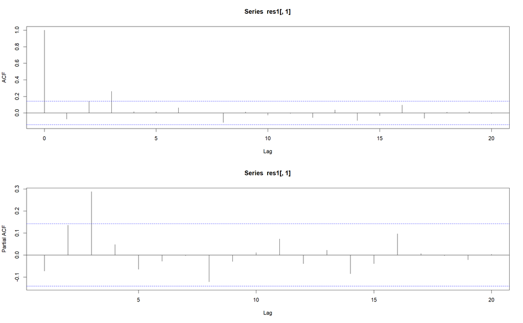

```r
par(mfrow = c(2,1))
acf(res1[,1], 20)
pacf(res1[,1], 20)
```

Non vanno molto bene, abbiamo ritardi significativi

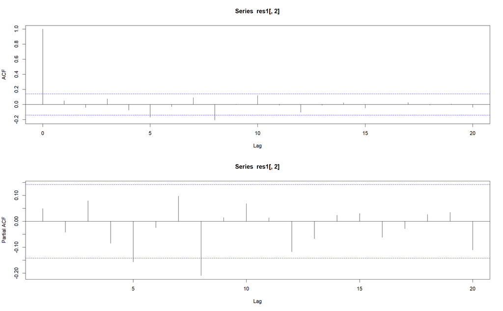

```r
par(mfrow = c(2,1))
acf(res1[,2], 20)
pacf(res1[,2], 20)
```

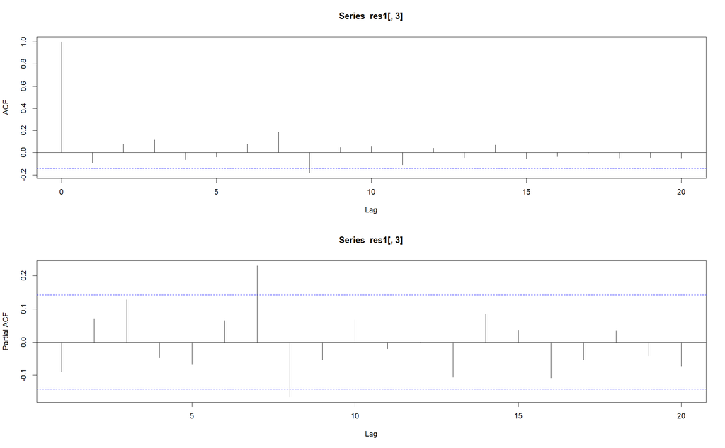

```r
par(mfrow = c(2,1))
acf(res1[,3], 20)
pacf(res1[,3], 20)
```

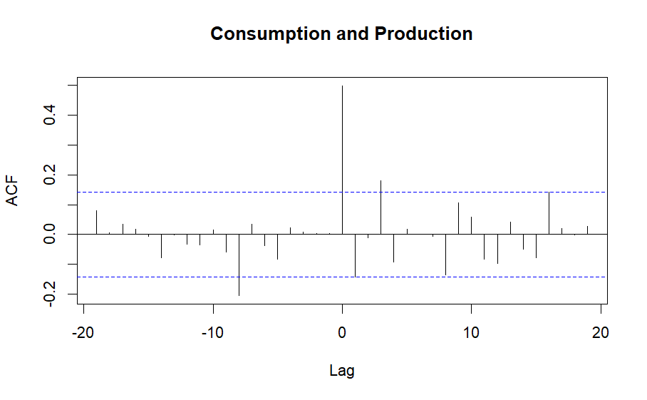

```r
par(mfrow = c(1,1))
ccf(res1[,1], res1[,2], main ="Consumption and Production")
```

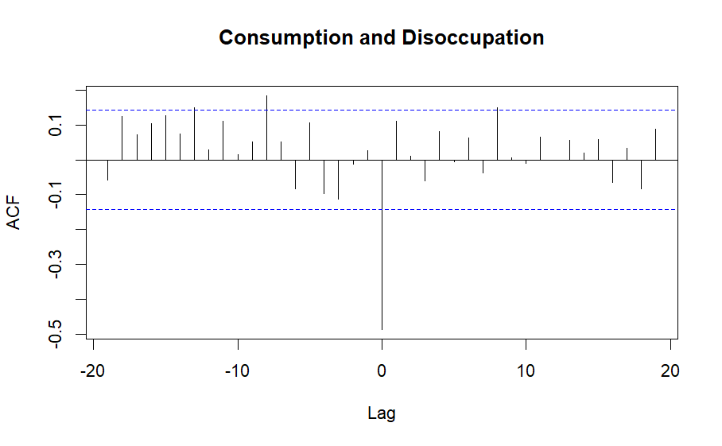

```r
ccf(res1[,1], res1[,3], main ="Consumption and Disoccupation")
```

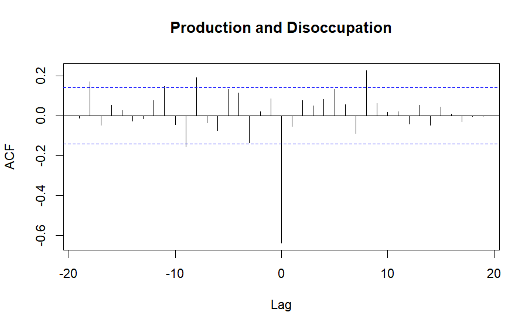

```r
ccf(res1[,2], res1[,3], main ="Production and Disoccupation")
par(mfrow = c(1,1))
```

```r
cor(res1)
```

```
             Consumption Production Unemployment
Consumption    1.0000000  0.4996182   -0.4875607
Production     0.4996182  1.0000000   -0.6391525
Unemployment  -0.4875607 -0.6391525    1.0000000
```

Il modello va benino, non riesce a tenere troppo conto della autocorrelazione nelle serie, ma per il resto è ok.

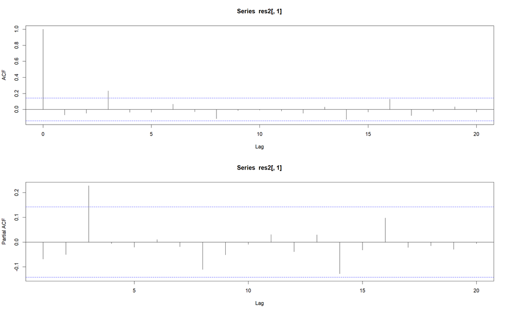

```r
par(mfrow = c(2,1))
acf(res2[,1], 20)
pacf(res2[,1], 20)
```

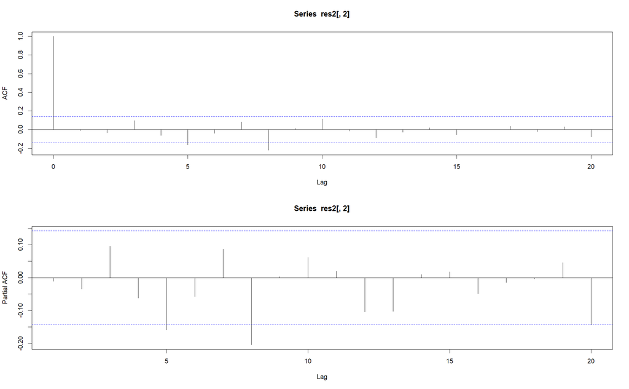

```r
par(mfrow = c(2,1))
acf(res2[,2], 20)
pacf(res2[,2], 20)
```

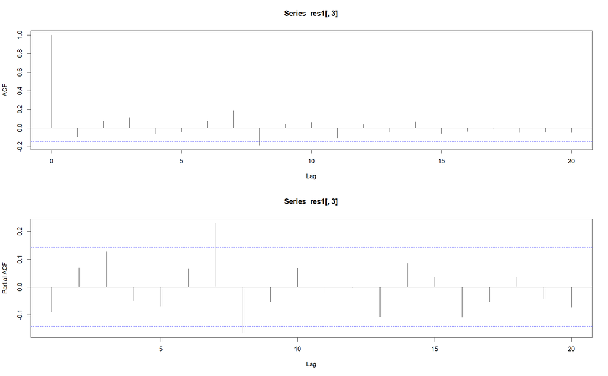

```r
par(mfrow = c(2,1))
acf(res1[,3], 20)
pacf(res1[,3], 20)
```

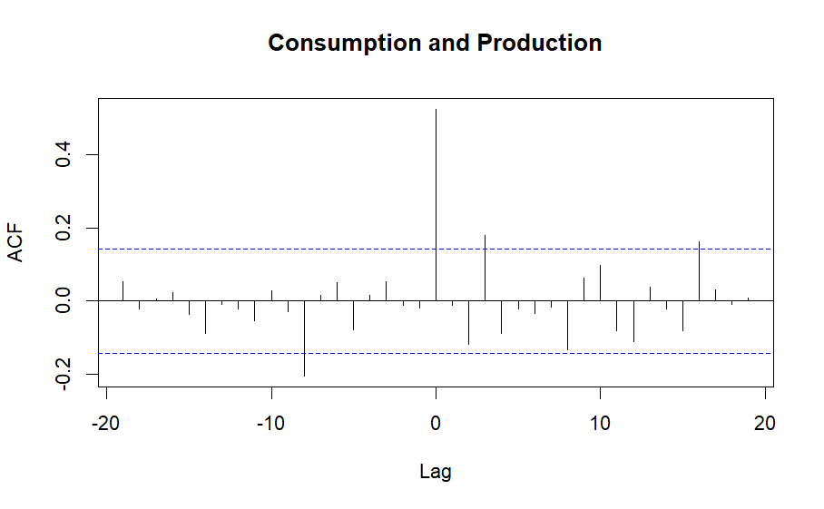

```r
par(mfrow = c(1,1))
ccf(res2[,1], res2[,2], main ="Consumption and Production")
```

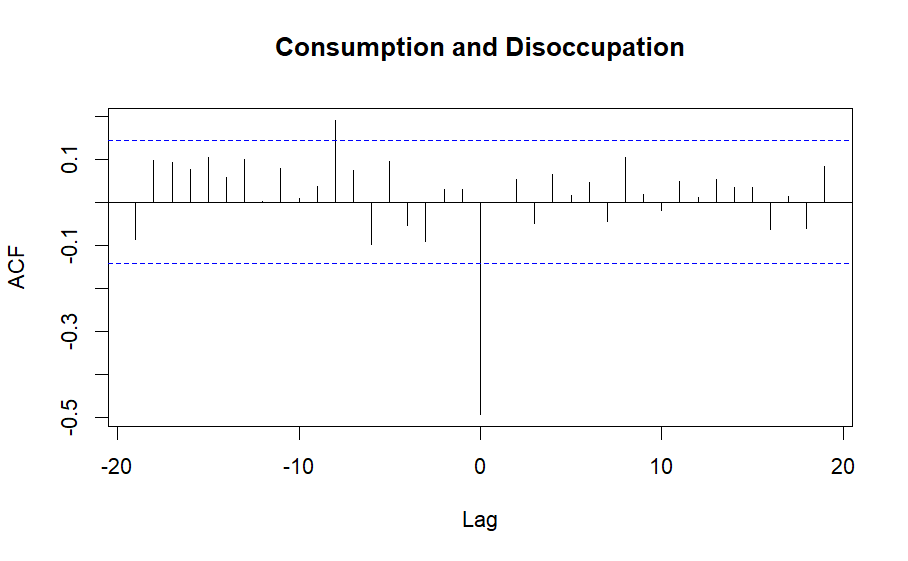

```r
ccf(res2[,1], res2[,3], main ="Consumption and Disoccupation")
```

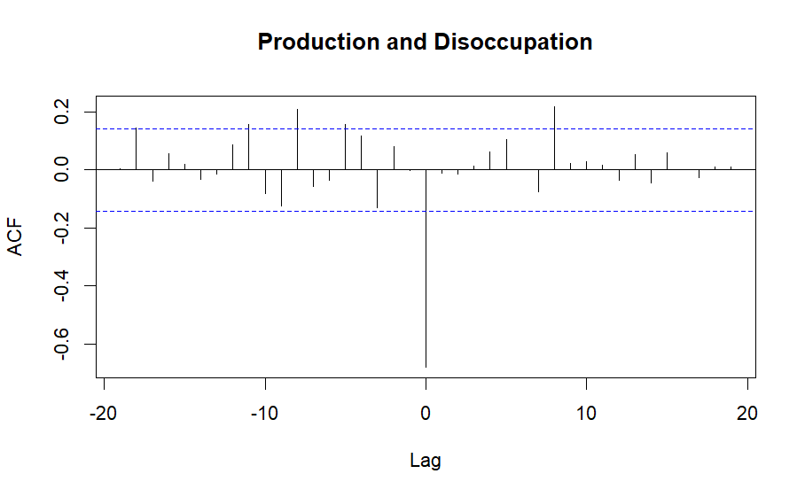

```r
ccf(res2[,2], res2[,3], main ="Production and Disoccupation")
par(mfrow = c(1,1))
```

```r
cor(res2)
```

```
             Consumption Production Unemployment
Consumption    1.0000000  0.5258318    -0.494292
Production     0.5258318  1.0000000    -0.680817
Unemployment  -0.4942920 -0.6808170     1.000000
```

Potremmo accontentarci di un VAR(2).

Dovremmo controllare per modelli anche in termini di previsioni.

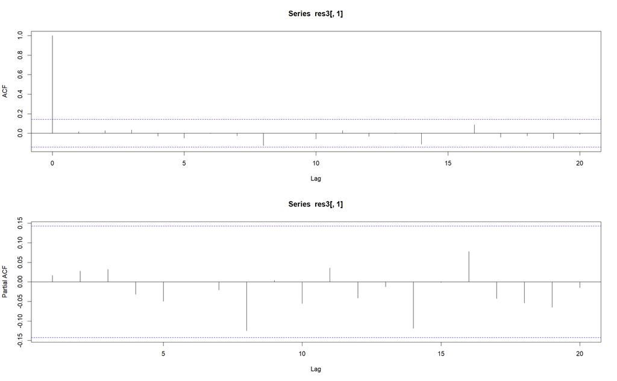

```r
par(mfrow = c(2,1))
acf(res3[,1], 20)
pacf(res3[,1], 20)
```

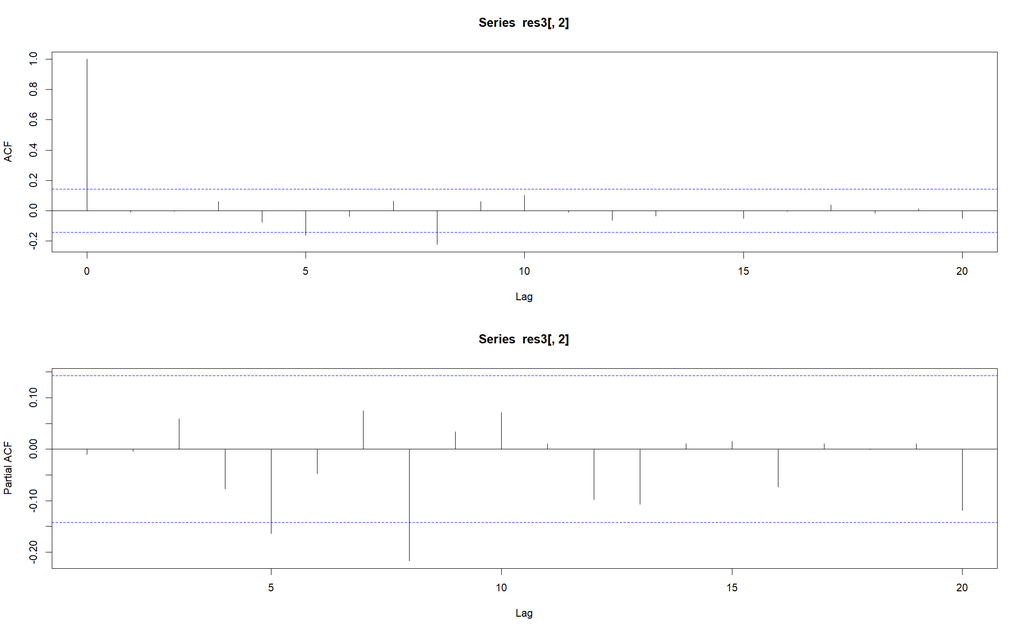

```r
par(mfrow = c(2,1))
acf(res3[,2], 20)
pacf(res3[,2], 20)
```

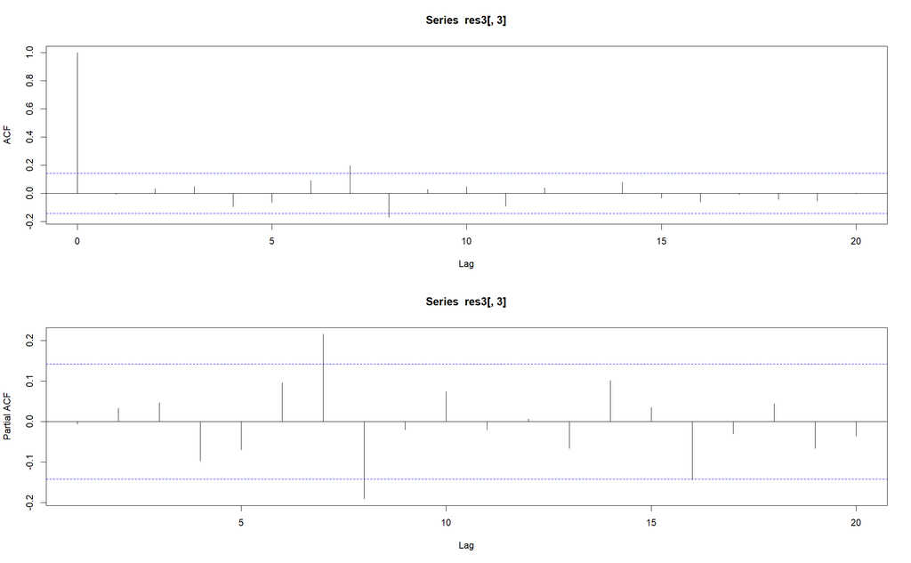

```r
par(mfrow = c(2,1))
acf(res3[,3], 20)
pacf(res3[,3], 20)
```

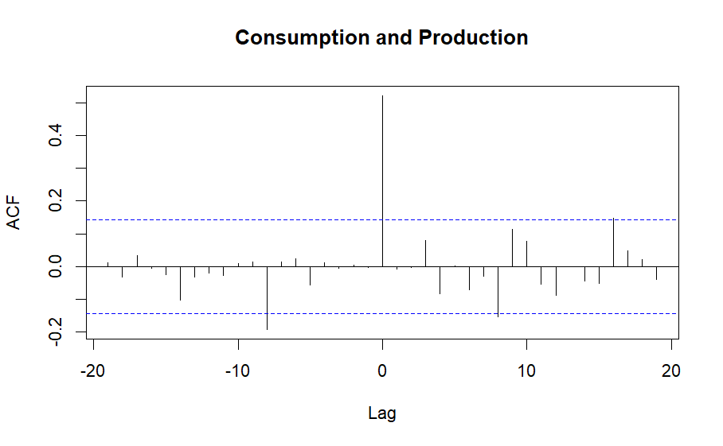

```r
par(mfrow = c(1,1))
ccf(res3[,1], res3[,2], main ="Consumption and Production")
```

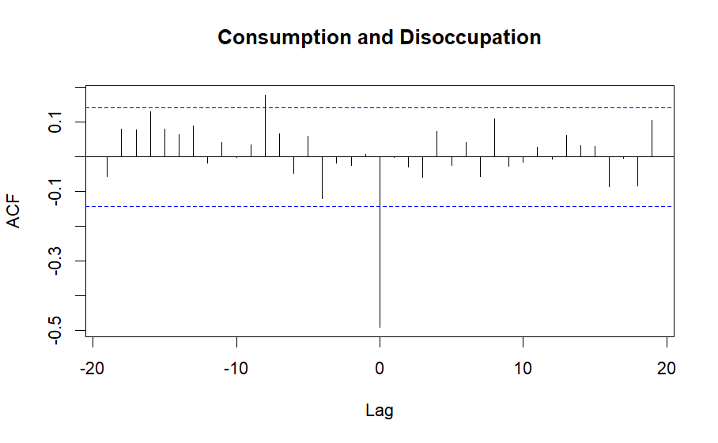

```r
ccf(res3[,1], res3[,3], main ="Consumption and Disoccupation")
```

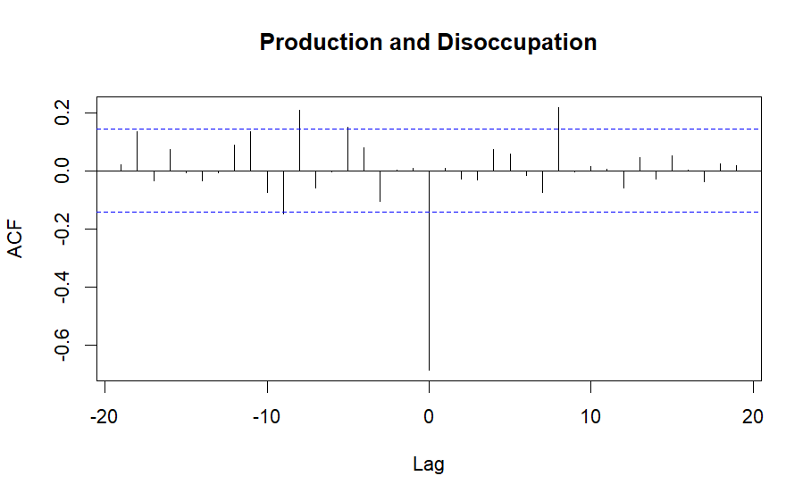

```r
ccf(res3[,2], res3[,3], main ="Production and Disoccupation")
par(mfrow = c(1,1))
```

```r
cor(res2)
```

```
             Consumption Production Unemployment
Consumption    1.0000000  0.5258318    -0.494292
Production     0.5258318  1.0000000    -0.680817
Unemployment  -0.4942920 -0.6808170     1.000000
```

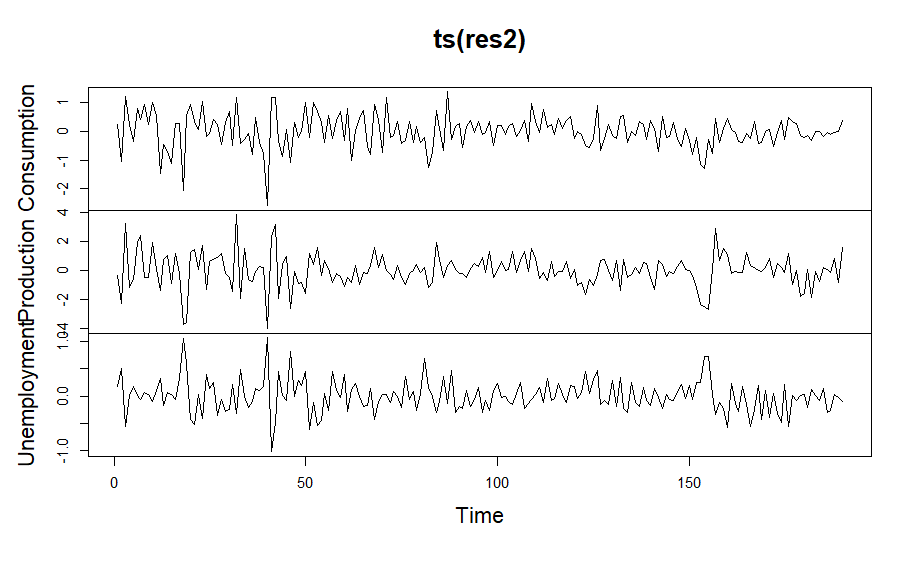

```r
plot(ts(res2))
```

```r
Box.test(res2[,2], lag = 10, type = "Lj")
```

```
    Box-Ljung test

data:  res2[, 2]
X-squared = 21.98, df = 10, p-value = 0.01521
```

Voglio capire se il mio modello è stazionario, ovvero devo prendere tutti i coeff e andare a avedere se le radici dell’equazione sono tutte in modulo < 1. Il comando darebbe errori se ci fossero problemi di non staionarietà.

Gli errori non per forza si distribuiscono come delle normali multivariate. Ha senso comunque effettuare un test per la normalità dei residui.

```r
roots(mod2) #controllo stazionarietà.
```

```
[1] 0.6344025 0.6344025 0.4789768 0.2744998 0.2495382 0.1585872
```

```r
normality.test(mod2) #controllo normalità dei residui.
```

```
$JB

    JB-Test (multivariate)

data:  Residuals of VAR object mod2
Chi-squared = 53.769, df = 6, p-value = 8.212e-10


$Skewness

    Skewness only (multivariate)

data:  Residuals of VAR object mod2
Chi-squared = 13.262, df = 3, p-value = 0.004103


$Kurtosis

    Kurtosis only (multivariate)

data:  Residuals of VAR object mod2
Chi-squared = 40.507, df = 3, p-value = 8.318e-09
```

Per la curtosi si ha che Ho: curtosi = 3.

Vengono inoltre fatti un test sulla simmetria e la curtosi, rifiuto Ho in tutti e tre i test.

Abbiamo una serie di test (con potenza bassa), rifiutiamo molto più spesso l’ipotesi alternativa del previsto.

Rifiuto ipotesi nulla incorrelazioni dei residui.

```r
serial.test(mod2, type = "PT.asymptotic")
```

```
    Portmanteau Test (asymptotic)

data:  Residuals of VAR object mod2
Chi-squared = 161.09, df = 126, p-value = 0.01903
```

```r
serial.test(mod2, lags.bg = 10, type = "BG")
```

```
    Breusch-Godfrey LM test

data:  Residuals of VAR object mod2
Chi-squared = 129.49, df = 90, p-value = 0.004071
```

#### PREVISIONI

Andiamo a vedere se questo modello prevede meglio di modelli univariati.

uso autoarima, che identifica il miglior modello tramite criteri di informazione automatica, non tramite funzioni coome acf e pacf. Bisogna tener conto degli operatori di differenziazione.

E’ difficile e ha poco senso confrontare modelli con d/D differenti perché sono modelli che misurano variabili e osservazioni differenti. uno misura yt e uno misura yt differenziato. Rischiamo di confrontare cose differenti. Dobbiamo fissare d/D a priori e correttamente.

Usiamo bic rispetto ad altri criteri perchè più parsimonioso.

```r
uni_cons = auto.arima(train[,1], ic = "bic", d = 0, D = 0)
fore_cons = forecast(uni_cons, h=nrow(test))

uni_cons
```

```
Series: train[, 1]
ARIMA(3,0,0) with non-zero mean

Coefficients:
         ar1     ar2     ar3    mean
      0.2070  0.1623  0.2221  0.7445
s.e.  0.0701  0.0707  0.0699  0.1003

sigma^2 = 0.3396:  log likelihood = -166.91
AIC=343.82   AICc=344.14   BIC=360.1
```

```r
uni_prod = auto.arima(train[,2], ic = "bic", d = 0, D = 0)
fore_prod = forecast(uni_prod, h=nrow(test))

uni_prod
```

```
Series: train[, 2]
ARIMA(1,0,0)(2,0,2)[4] with non-zero mean

Coefficients:
         ar1    sar1     sar2     sma1    sma2    mean
      0.6004  0.6854  -0.3751  -0.7820  0.1331  0.5118
s.e.  0.0584  0.3342   0.2759   0.3493  0.3462  0.1099

sigma^2 = 1.4:  log likelihood = -302.63
AIC=619.27   AICc=619.88   BIC=642.07
```

```r
uni_une = auto.arima(train[,3], ic = "bic", d = 0, D = 0)
fore_une = forecast(uni_une, h=nrow(test))

uni_une
```

```
Series: train[, 3]
ARIMA(2,0,0)(1,0,1)[4] with zero mean

Coefficients:
         ar1     ar2    sar1     sma1
      0.4326  0.2658  0.3926  -0.7122
s.e.  0.0732  0.0790  0.1298   0.0953

sigma^2 = 0.08873:  log likelihood = -38.46
AIC=86.92   AICc=87.24   BIC=103.21
```

Devo sempre giustificare i valori dei parametri che scelgo, ovvero la scelta del criterio, d, D, P max, D max. Va sempre specificato e giustificato tutto.

Oppure posso fare un’identificazione strutturale. Auto arima può essere usato come spunto.

```r
mean_funi = cbind(fore_cons$mean,
                  fore_prod$mean,
                  fore_une$mean)

fore_cons
```

|  | Point Forecast | Lo 80 | Hi 80 | Lo 95 | Hi 95 |
| --- | --- | --- | --- | --- | --- |
| 2018 Q1 | 0.7654045 | 0.01861535 | 1.512194 | -0.3767109 | 1.907520 |
| 2018 Q2 | 0.7764063 | 0.01378616 | 1.539026 | -0.3899206 | 1.942733 |
| 2018 Q3 | 0.8408350 | 0.06298279 | 1.618687 | -0.3487873 | 2.030457 |
| 2018 Q4 | 0.7742650 | -0.03483564 | 1.583366 | -0.4631476 | 2.011678 |
| 2019 Q1 | 0.7733844 | -0.04253855 | 1.589307 | -0.4744621 | 2.021231 |
| 2019 Q2 | 0.7767120 | -0.04437673 | 1.597801 | -0.4790349 | 2.032459 |

```r
fore_prod
```

|  | Point Forecast | Lo 80 | Hi 80 | Lo 95 | Hi 95 |
| --- | --- | --- | --- | --- | --- |
| 2018 Q1 | 1.5359863 | 0.01937296 | 3.052600 | -0.7834736 | 3.855446 |
| 2018 Q2 | 1.3862478 | -0.38275825 | 3.155254 | -1.3192135 | 4.091709 |
| 2018 Q3 | 0.8926684 | -0.95891465 | 2.744251 | -1.9390835 | 3.724420 |
| 2018 Q4 | 0.9404403 | -0.94002529 | 2.820906 | -1.9354836 | 3.816364 |
| 2019 Q1 | 0.8438398 | -1.03730872 | 2.724988 | -2.0331286 | 3.720808 |
| 2019 Q2 | 0.6562025 | -1.22519219 | 2.537597 | -2.2211424 | 3.533547 |

```r
fore_une
```

|  | Point Forecast | Lo 80 | Hi 80 | Lo 95 | Hi 95 |
| --- | --- | --- | --- | --- | --- |
| 2018 Q1 | -0.025916987 | -0.4076535 | 0.3558195 | -0.6097326 | 0.5578986 |
| 2018 Q2 | -0.035814790 | -0.4517379 | 0.3801083 | -0.6719143 | 0.6002847 |
| 2018 Q3 | -0.002722759 | -0.4531460 | 0.4477004 | -0.6915856 | 0.6861401 |
| 2018 Q4 | 0.079990068 | -0.3858043 | 0.5457844 | -0.6323809 | 0.7923611 |
| 2019 Q1 | 0.051122997 | -0.4153264 | 0.5175724 | -0.6622498 | 0.7644958 |
| 2019 Q2 | 0.044147569 | -0.4227675 | 0.5110627 | -0.6699375 | 0.7582326 |

```r
mean_funi
```

```
        fore_cons$mean fore_prod$mean fore_une$mean
2018 Q1      0.7654045      1.5359863  -0.025916987
2018 Q2      0.7764063      1.3862478  -0.035814790
2018 Q3      0.8408350      0.8926684  -0.002722759
2018 Q4      0.7742650      0.9404403   0.079990068
2019 Q1      0.7733844      0.8438398   0.051122997
2019 Q2      0.7767120      0.6562025   0.044147569
```

```r
colnames(mean_funi) = colnames(train)
```

Prendiamo solo le previsioni puntuali e le inseriamo nella matrice.

Andiamo a prendere le previsioni multivariate dai modelli VAR

```r
fmod1 = predict(mod1, n.ahead = 6)
fmod2 = predict(mod2, n.ahead = 6)
fmod3 = predict(mod3, n.ahead = 6)
```

Prendo solo la prima colonna. ovvero la colonna con le prev

```r
mean_f1 = sapply(fmod1$fcst, function(x) x[,1])
mean_f2 = sapply(fmod2$fcst, function(x) x[,1])
mean_f3 = sapply(fmod3$fcst, function(x) x[,1])
```

Ci costruiamo gli errori di previsione.

```r
table.mse = rbind(L1 = colMeans((mean_f1-test)^2),
                  L2 = colMeans((mean_f2-test)^2),
                  L3 = colMeans((mean_f3-test)^2),
                  ARIMA = colMeans((mean_funi-test)^2))
round(table.mse,4)
```

```
      Consumption Production Unemployment
L1         0.1247     0.5443       0.0230
L2         0.1052     0.5512       0.0216
L3         0.1103     0.5652       0.0238
ARIMA      0.1155     0.7257       0.0255
```

```r
apply(table.mse, 2, rank)
```

```
      Consumption Production Unemployment
L1              4          1            2
L2              1          2            1
L3              2          3            3
ARIMA           3          4            4
```

Per il consumo il modello migliore in termini previsione è L2, per la produzione L1 e per la disoccupazione L2.

```r
table.msa = rbind(L1 = colMeans(abs((mean_f1-test)^2)),
                  L2 = colMeans(abs((mean_f2-test)^2)),
                  L3 = colMeans(abs((mean_f3-test)^2)),
                  ARIMA = colMeans(abs((mean_funi-test)^2)))
round(table.msa,4)
```

```
      Consumption Production Unemployment
L1         0.1247     0.5443       0.0230
L2         0.1052     0.5512       0.0216
L3         0.1103     0.5652       0.0238
ARIMA      0.1155     0.7257       0.0255
```

```r
apply(table.msa, 2, rank)
```

```
      Consumption Production Unemployment
L1              4          1            2
L2              1          2            1
L3              2          3            3
ARIMA           3          4            4
```

Più aumenta l’intervallo previsivo più aumenta la varianza delle mie previsioni, dato l’aumento di incertezza delle informazioni. Dato che utilizzo previsioni per previsioni.

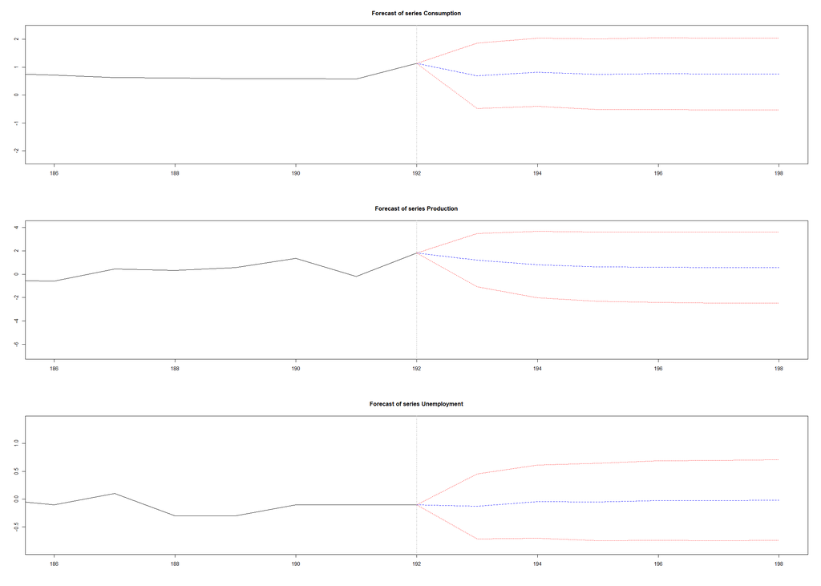

```r
plot(fmod2, xlim = c(186, 198))
```

:)